# An Intro to R, Rstudio, and `{tidyverse}`

Steven V. Miller, svmiller.com

23 Nov. 2022

Abstract

This is a lab script for [EH6105](http://eh6105.svmiller.com), a graduate-level quantitative methods class that I teach at Stockholm University. It will not be the most sophisticated R-related write-up of mine—check [my blog](http://svmiller.com/blog) for those—but it should be useful for discussion around the associated R script for the week’s ‘lab’ session.

# Elsewhere in the R `"Steveverse"`

Some of what I offer here may be (aggressively) plagiarized from other resources I’ve made available. In particular, check out [this near identical guide](http://post8000.svmiller.com/lab-scripts/intro-r-rstudio.html) I made available for graduate students at my previous employer. I have [a somewhat dated guide](http://svmiller.com/blog/2014/08/a-beginners-guide-to-using-r/) on my website too.

# Configure Rstudio

When you’re opening R for the very first time, it’ll be useful to just get a general sense of what’s happening. I have [a beginner’s guide that I wrote in 2014](http://svmiller.com/blog/2014/08/a-beginners-guide-to-using-r/) (where did the time go!). Notice that I built it around [Rstudio](https://rstudio.com/products/rstudio/), which you should download as well. Rstudio desktop is free. Don’t pay for a “pro” version. You’re not running a server. You won’t need it.

When you download and install Rstudio *on top* of R, you should customize it just a tiny bit to make the most of the graphical user interface. To do what I recommend doing, select “Tools” in the menu. Scroll to “global options” (which should be at the bottom). On the pop-up, select “pane layout.” Rearrange it so that “Source” is top left, “Console” is top right, and the files/plots/packages/etc. is the bottom right. Thereafter: apply the changes.

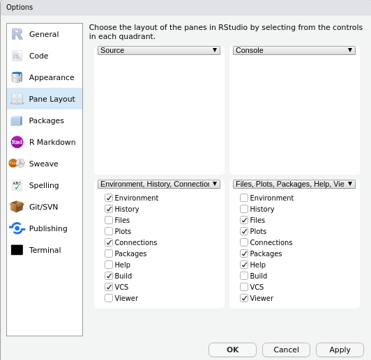

You don’t have to do this, but I think you should since it better economizes space in Rstudio. The other pane (environment/history, Git, etc.) is stuff you can either learn to not need (e.g. what’s in the environment) or will only situationally need at an advanced level (e.g. Git information). Minimize that outright. When you’re in Rstudio, much of what you’ll be doing leans on the script window and the console window. You’ll occasionally be using the file browser and plot panes as well.

If you have not done so already, open a new script (Ctrl-Shift-N in Windows/Linux or Cmd-Shift-N in Mac) to open a new script.

# Get Acclimated in R

Now that you’ve done that, let’s get a general sense of where you are in an R session.

## Current Working Directory

First, let’s start with identifying the current working directory. You should know where you are and this happens to be where I am, given the location of this script.

```r
getwd()
```

```
## [1] "/home/steve/Dropbox/teaching/eh6105/lab-scripts"
```

Of note: by default, R’s working directory is the system’s “home” directory. This is somewhat straightforward in Unix-derivative systems, where there is an outright “home” directory. Assume your username is “steve”, then, in Linux, your home directory will be “/home/steve”. In Mac, I think it’s something like “/Users/steve”. Windows users will invariably have something clumsy like “C:/Users/steve/Documents”. Notice the forward slashes. R, like everything else in the world, uses forward slashes. The backslashes owe to Windows’ derivation from DOS.

## Create “Objects”

Next, let’s create some “objects.” R is primarily an “object-oriented” programming language. In as many words, inputs create outputs that may be assigned to objects in the workspace. You can go nuts here. Of note: I’ve seen R programmers use `=`, `->`, and `<-` interchangeably for object assignment, but I’ve seen instances where `=` doesn’t work as intended for object assignment. `->` is an option and I use it for assignment for some complex objects in a “pipe” (more on that later). For simple cases (and for beginners), lean on `<-`.

```r
a <- 3
b <- 4
A <- 7
a + b
```

```
## [1] 7
```

```r
A + b
```

```
## [1] 11
```

```r
# what objects did we create?
# Notice we did not save a + b or A + b to an object
# Also notice how a pound sign creates a comment? Kinda cool, right? Make comments to yourself.
ls()
```

```
## [1] "a" "A" "b"
```

Some caution, though. First, don’t create objects with really complex names. To call them back requires getting every character right in the console or script. Why inconvenience yourself? Second, R comes with some default objects that are kinda important and can seriously ruin things downstream. I don’t know off the top of my head all the default objects in R, but there are some important ones like `TRUE`, and `FALSE` that you DO NOT want to overwrite. `pi` is another one you should not overwrite, and `data` is a function that serves a specific purpose (even if you probably won’t be using it a whole lot). You can, however, assign some built-in objects to new objects.

```r
this_Is_a_long_AND_WEIRD_objEct_name_and_yOu_shoUld_not_do_this <- 5
pi # notice there are a few built-in functions/objects
```

```
## [1] 3.141593
```

```r
d <- pi # you can assign one built-in object to a new object.
# pi <- 3.14 # don't do this....
```

If you do something dumb (like overwrite `TRUE` with something), all hope is not lost. Just remove the object in question with the `rm()` command.

## Install/Load Libraries

R depends on user-created libraries to do much of its functionality. This class will lean on just a few R libraries. The first, `{tidyverse}` is our workhorse for workflow. It’ll also be the longest to install because it comes with lots of dependencies to maximize its functionality. [`{stevedata}`](http://svmiller.com/stevedata) contains toy data sets that I use for in-class instruction, and we’ll make use of these data in these lab sessions (and in your problem sets). [`{stevemisc}`](http://svmiller.com/stevemisc) contains assorted helper functions that I wrote for my research, which we’ll also use in this class. [`{stevetemplates}`](http://svmiller.com/stevetemplates) is not strictly necessary, but it will make doing your homeworks infinitely easier (even if you’re not a LaTeX user). `{lmtest}`, which is not a package I maintain, does various model diagnostics for OLS.

I *may*—and probably will, to be honest—ask you to install various other packages that I think you should have installed. Already, I can see that the last problem set is going to be a “choose your adventure” at the end, and request that you have either the `{fixest}` or `{modelr}` package installed. I hope to keep these situations to a minimum.

If any of these result in a “non-zero exit status”, that’s R’s way of saying “I couldn’t install this.” For you Mac users, the answer to this situation is *probably* “update [Xcode](https://developer.apple.com/xcode/).” Xcode is a developer tool suite for Apple, and many of the `{tidyverse}` packages require access to developmental libraries that, to the best of my understanding, are available in Xcode. In all likelihood, you’re a first-time user who has not had to think about software development (and so you haven’t updated Xcode since you first got your Macbook). You might have to do that here.

For you Windows users: I think I’ve figured out what this may look like for you based on my recent foray into the university’s computer labs. The Windows corollary to Xcode is Rtools, which you *don’t* have installed by default (because it’s not a Microsoft program, per se). You’ll need to install it. First, take inventory of what version of R you have (for the university’s computer labs, it should be 4.0.5). [Go to this website](https://cran.r-project.org/bin/windows/Rtools/) and download the version of Rtools that corresponds with the version of R you have. Just click through all the default options so that it can install. Next, in Rstudio, open a new blank file and copy-paste the following code into it.

```r
# PATH="${RTOOLS40_HOME}\usr\bin;${PATH}"
```

I’ll add the caveat that you should remove the hashtag and space preceding that line.

Next, save the file as `.Renviron` in your default working directory, which is probably where you are if you are using Rstudio for the first time. The save prompt from Rstudio will advise you that this is no longer an `.R` file (and, duh, just tell it to save anyway). Afterwards, restart Rstudio and try again. This *should* fix it, based on my recent trial run in the university’s computer labs.

For you Linux users: you’re awesome, have great hair, everyone likes you, and you don’t need to worry about a thing, *except* the various developmental libraries you may have to install from your package repository. My flavor of Linux is in the Debian/Ubuntu family, so [here’s an (incomplete) list of developmental libraries](http://svmiller.com/blog/2019/07/notes-to-self-new-linux-installation-r-ubuntu/) based on my experience. Helpfully, most R packages that fail this way will tell you what development library you need, whether in you’re in the Debian or Red Hat family.

If you have yet to install these packages (and you almost certainly have not if you’re opening R for the first time), install it as follows. Note that I’m just commenting out this command so it doesn’t do this when I compile this script on my end.

```r
# Take out the comment...
# install.packages(c("tidyverse", "stevedata", "stevemisc", "stevetemplates", "lmtest"))
```

Once they’re all installed, you can load the libraries with the `library()` command. Of note: you only need to install a package once, but you’ll need to load the library for each R session. You won’t really need to load `{stevetemplates}` for anything since it’s core functionality is its integration with Rstudio. Let’s load `{tidyverse}` and `{stevedata}` in this session, since it’s what I’ll typically use.

```r
library(tidyverse)
library(stevedata)
```

For those of you that are having `{tidyverse}` installation issues because of `{systemfonts}` needing some font-related development libraries, try this:

```r
library(tibble)    # special data type we'll use
library(magrittr)  # pipe operator
library(dplyr)     # the workhorse
library(readr)     # for reading particular data types.
library(stevedata) # for data
```

Problem sets and lab scripts will lean on data I make available in `{stevedata}`. However, you may often find that you want to download a data set from somewhere else and load it into R. Example data sets would be stuff like European Values Survey, European Social Survey, or Varieties of Democracy, or whatever else. You can do this any number of ways, and it will depend on what is the file format you downloaded. Here are some commands you’ll want to learn for these circumstances:

- `haven::read_dta()`: for loading Stata .dta files
- `haven::read_spss()`: for loading SPSS binaries (typically .sav files)
- `read_csv()`: for loading comma-separated values (CSV) files
- `readxl::read_excel()`: for loading MS Excel spreadsheets.
- `read_tsv()`: for tab-separated values (TSV) files
- `readRDS()`: for R serialized data frames, which are awesome for file compression/speed.

Notice that functions like `read_dta()`, `read_spss()`, and `read_excel()` require some other packages that I didn’t mention. However, these other packages/libraries are part of the `{tidyverse}` and are just not loaded directly with them. Under these conditions, you can avoid directly loading a library into a session by referencing it first and grabbing the function you want from within it separated by two colons (`::`). Basically, `haven::read_dta()` could be interpreted as a command saying “using the `{haven}` library, grab the `read_dta()` command in it”.

These wrappers are also flexible with files on the internet. For example, these will work. Just remember to assign them to an object.

```r
# Note: hypothetical data
Apply <- haven::read_dta("https://stats.idre.ucla.edu/stat/data/ologit.dta")

# Let's take a look at these data.
Apply
```

```
## # A tibble: 400 × 4
##    apply               pared public   gpa
##    <dbl+lbl>           <dbl>  <dbl> <dbl>
##  1 2 [very likely]         0      0  3.26
##  2 1 [somewhat likely]     1      0  3.21
##  3 0 [unlikely]            1      1  3.94
##  4 1 [somewhat likely]     0      0  2.81
##  5 1 [somewhat likely]     0      0  2.53
##  6 0 [unlikely]            0      1  2.59
##  7 1 [somewhat likely]     0      0  2.56
##  8 1 [somewhat likely]     0      0  2.73
##  9 0 [unlikely]            0      0  3
## 10 1 [somewhat likely]     1      0  3.5
## # ℹ 390 more rows
```

## Learn Some Important R/“Tidy” Functions

I want to spend most of our time in this lab session teaching you some basic commands you should know to do basically anything in R. These are so-called “tidy” verbs. We’ll be using some data available in `{stevedata}`. This is the `pwt_sample` data, which includes yearly economic data for a handful of rich countries that are drawn from version 10.0 of the Penn World Table. If you’re in Rstudio, you can learn more about these data by typing the following command.

```r
?pwt_sample
```

I want to dedicate the bulk of this section to learning some core functions that are part of the `{tidyverse}`. My introduction here will inevitably be incomplete because there’s only so much I can teach within the limited time I have. That said, I’m going to focus on the following functions available in the `{tidyverse}` that totally rethink base R. These are the “pipe” (`%>%`), `glimpse()` and `summary()`, `select()`, `group_by()`, `summarize()`, `mutate()`, and `filter()`.

### The Pipe (`%>%`)

I want to start with the pipe because I think of it as the most important function in the `{tidyverse}`. The pipe—represented as `%>%`—allows you to chain together a series of functions. The pipe is especially useful if you’re recoding data and you want to make sure you got everything the way you wanted (and correct) before assigning the data to another object. You can chain together *a lot* of `{tidyverse}` commands with pipes, but we’ll keep our introduction here rather minimal because I want to use it to teach about some other things.

### `glimpse()` and `summary()`

`glimpse()` and `summary()` will get you basic descriptions of your data. Personally, I find `summary()` more informative than `glimpse()` though `glimpse()` is useful if your data have a lot of variables and you want to just peek into the data without spamming the R console without output.

Notice, here, the introduction of the pipe (`%>%`). In the commands below, `pwt_sample %>% glimpse()` is equivalent to `glimpse(pwt_sample)`, but I like to lean more on pipes than perhaps others would. My workflow starts with (data) objects, applies various functions to them, and assigns them to objects. I think you’ll get a lot of mileage thinking that same way too.

```r
pwt_sample %>% glimpse() # notice the pipe
```

```
## Rows: 1,540
## Columns: 12
## $ country <chr> "Australia", "Australia", "Australia", "Australia", "Australia…
## $ isocode <chr> "AUS", "AUS", "AUS", "AUS", "AUS", "AUS", "AUS", "AUS", "AUS",…
## $ year    <int> 1950, 1951, 1952, 1953, 1954, 1955, 1956, 1957, 1958, 1959, 19…
## $ pop     <dbl> 8.354106, 8.599923, 8.782430, 8.950892, 9.159148, 9.374454, 9.…
## $ hc      <dbl> 2.667302, 2.674344, 2.681403, 2.688482, 2.695580, 2.702696, 2.…
## $ rgdpna  <dbl> 127461.2, 130703.1, 125353.1, 138952.2, 150060.7, 155979.7, 15…
## $ rgdpo   <dbl> 114135.0, 110543.1, 108883.4, 122688.5, 131836.4, 138380.6, 14…
## $ rgdpe   <dbl> 121994.0, 113929.4, 111219.9, 123328.9, 131472.1, 136247.3, 13…
## $ labsh   <dbl> 0.6804925, 0.6804925, 0.6804925, 0.6804925, 0.6804925, 0.68049…
## $ avh     <dbl> 2170.923, 2150.847, 2130.956, 2111.249, 2091.725, 2072.381, 20…
## $ emp     <dbl> 3.429873, 3.523916, 3.591675, 3.653409, 3.731083, 3.811291, 3.…
## $ rnna    <dbl> 639991.2, 690113.6, 704562.4, 733107.3, 771454.2, 810403.7, 83…
```

```r
pwt_sample %>% summary()
```

```
##    country            isocode               year           pop
##  Length:1540        Length:1540        Min.   :1950   Min.   :  0.1432
##  Class :character   Class :character   1st Qu.:1967   1st Qu.:  6.4060
##  Mode  :character   Mode  :character   Median :1984   Median : 10.5915
##                                        Mean   :1984   Mean   : 35.5251
##                                        3rd Qu.:2002   3rd Qu.: 50.7108
##                                        Max.   :2019   Max.   :329.0649
##                                                       NA's   :2
##        hc            rgdpna             rgdpo              rgdpe
##  Min.   :1.242   Min.   :    1213   Min.   :    1329   Min.   :    1234
##  1st Qu.:2.472   1st Qu.:  151193   1st Qu.:  117905   1st Qu.:  117703
##  Median :2.838   Median :  328992   Median :  291610   Median :  295257
##  Mean   :2.814   Mean   : 1139533   Mean   : 1070787   Mean   : 1066654
##  3rd Qu.:3.202   3rd Qu.: 1103018   3rd Qu.:  939821   3rd Qu.:  933379
##  Max.   :3.774   Max.   :20563592   Max.   :20596346   Max.   :20856496
##  NA's   :2       NA's   :2          NA's   :2          NA's   :2
##      labsh             avh            emp                 rnna
##  Min.   :0.3168   Min.   :1381   Min.   :  0.06547   Min.   :    8340
##  1st Qu.:0.5663   1st Qu.:1679   1st Qu.:  2.91308   1st Qu.:  808493
##  Median :0.6211   Median :1849   Median :  4.56337   Median : 1992211
##  Mean   :0.6088   Mean   :1857   Mean   : 16.13788   Mean   : 5439111
##  3rd Qu.:0.6446   3rd Qu.:2032   3rd Qu.: 20.71151   3rd Qu.: 5306239
##  Max.   :0.7709   Max.   :2528   Max.   :158.29959   Max.   :69059064
##  NA's   :2        NA's   :17     NA's   :2           NA's   :2
```

### `select()`

`select()` is useful for basic (but important) data management. You can use it to grab (or omit) columns from data. For example, let’s say I wanted to grab all the columns in the data. I could do that with the following command.

```r
pwt_sample %>% select(everything())  # grab everything
```

```
## # A tibble: 1,540 × 12
##    country   isocode  year   pop    hc  rgdpna   rgdpo   rgdpe labsh   avh   emp
##    <chr>     <chr>   <int> <dbl> <dbl>   <dbl>   <dbl>   <dbl> <dbl> <dbl> <dbl>
##  1 Australia AUS      1950  8.35  2.67 127461. 114135. 121994. 0.680 2171.  3.43
##  2 Australia AUS      1951  8.60  2.67 130703. 110543. 113929. 0.680 2151.  3.52
##  3 Australia AUS      1952  8.78  2.68 125353. 108883. 111220. 0.680 2131.  3.59
##  4 Australia AUS      1953  8.95  2.69 138952. 122688. 123329. 0.680 2111.  3.65
##  5 Australia AUS      1954  9.16  2.70 150061. 131836. 131472. 0.680 2092.  3.73
##  6 Australia AUS      1955  9.37  2.70 155980. 138381. 136247. 0.680 2072.  3.81
##  7 Australia AUS      1956  9.60  2.71 156338. 140420. 139239. 0.680 2053.  3.90
##  8 Australia AUS      1957  9.81  2.72 159762. 141453. 139158. 0.680 2034.  3.95
##  9 Australia AUS      1958 10.0   2.73 170599. 152677. 148572. 0.680 2015.  3.98
## 10 Australia AUS      1959 10.2   2.74 181049. 162661. 159401. 0.680 1997.  4.03
## # ℹ 1,530 more rows
## # ℹ 1 more variable: rnna <dbl>
```

Do note this is kind of a redundant command. You could just as well spit the entire data into the console and it would’ve done the same thing. Still, here’s if I wanted everything except wanted to drop the labor share of income variable.

```r
pwt_sample %>% select(-labsh) # grab everything, but drop the labsh variable.
```

```
## # A tibble: 1,540 × 11
##    country   isocode  year   pop    hc  rgdpna   rgdpo  rgdpe   avh   emp   rnna
##    <chr>     <chr>   <int> <dbl> <dbl>   <dbl>   <dbl>  <dbl> <dbl> <dbl>  <dbl>
##  1 Australia AUS      1950  8.35  2.67 127461. 114135. 1.22e5 2171.  3.43 6.40e5
##  2 Australia AUS      1951  8.60  2.67 130703. 110543. 1.14e5 2151.  3.52 6.90e5
##  3 Australia AUS      1952  8.78  2.68 125353. 108883. 1.11e5 2131.  3.59 7.05e5
##  4 Australia AUS      1953  8.95  2.69 138952. 122688. 1.23e5 2111.  3.65 7.33e5
##  5 Australia AUS      1954  9.16  2.70 150061. 131836. 1.31e5 2092.  3.73 7.71e5
##  6 Australia AUS      1955  9.37  2.70 155980. 138381. 1.36e5 2072.  3.81 8.10e5
##  7 Australia AUS      1956  9.60  2.71 156338. 140420. 1.39e5 2053.  3.90 8.38e5
##  8 Australia AUS      1957  9.81  2.72 159762. 141453. 1.39e5 2034.  3.95 8.67e5
##  9 Australia AUS      1958 10.0   2.73 170599. 152677. 1.49e5 2015.  3.98 9.05e5
## 10 Australia AUS      1959 10.2   2.74 181049. 162661. 1.59e5 1997.  4.03 9.47e5
## # ℹ 1,530 more rows
```

```r
pwt_sample %>% select(country, year, rgdpna) # grab just these three columns.
```

```
## # A tibble: 1,540 × 3
##    country    year  rgdpna
##    <chr>     <int>   <dbl>
##  1 Australia  1950 127461.
##  2 Australia  1951 130703.
##  3 Australia  1952 125353.
##  4 Australia  1953 138952.
##  5 Australia  1954 150061.
##  6 Australia  1955 155980.
##  7 Australia  1956 156338.
##  8 Australia  1957 159762.
##  9 Australia  1958 170599.
## 10 Australia  1959 181049.
## # ℹ 1,530 more rows
```

### Grouping data for grouped functions (`group_by()`, or `.by=`)

I think the pipe is probably the most important function in the `{tidyverse}` even as a critical reader might note that the pipe is 1) a port from another package (`{magrittr}`) and 2) now a part of base R in a different terminology. Thus, the critical reader (and probably me, depending on my mood) may note that grouping functions— whether through `group_by()` or `.by`—is probably the most important component of the `{tidyverse}`. Basically, `group_by()` allows you to “split” the data into various subsets, “apply” various functions to them, and “combine” them into one output. You might see that terminology “split-apply-combine” as you learn more about the `{tidyverse}` and its development.

Here, let’s do a simple `group_by()` exercise, while also introducing you to another function: `slice()`. We’re going to group by country in `pwt_sample` and “slice” the first observation for each group/country. Notice how we can chain these together with a pipe operator.

```r
# Notice we can chain some pipes together
pwt_sample %>%
  # group by country
  group_by(country) %>%
  # Get me the first observation, by group.
  slice(1)
```

```
## # A tibble: 22 × 12
## # Groups:   country [22]
##    country  isocode  year   pop    hc  rgdpna   rgdpo   rgdpe  labsh   avh   emp
##    <chr>    <chr>   <int> <dbl> <dbl>   <dbl>   <dbl>   <dbl>  <dbl> <dbl> <dbl>
##  1 Austral… AUS      1950  8.35  2.67 127461. 114135. 121994.  0.680 2171.  3.43
##  2 Austria  AUT      1950  6.98  2.55  56938.  41645.  40430.  0.633 2086.  2.93
##  3 Belgium  BEL      1950  8.63  2.20  85076.  72068.  75250.  0.645 2096.  3.46
##  4 Canada   CAN      1950 13.8   2.48 198071. 176435. 170050.  0.769 2209.  6.12
##  5 Chile    CHL      1950 NA    NA        NA      NA      NA  NA       NA  NA
##  6 Denmark  DNK      1950  4.27  2.84  54773.  45143.  44974.  0.642 2050.  1.97
##  7 Finland  FIN      1950  4.01  2.12  29957.  26424.  25824.  0.692 2025.  2.19
##  8 France   FRA      1950 42.5   2.18 372194. 324790. 325674.  0.668 2351. 19.6
##  9 Germany  DEU      1950 68.7   2.43 495069. 358993. 351956.  0.668 2428. 30.9
## 10 Greece   GRC      1950 NA    NA        NA      NA      NA  NA       NA  NA
## # ℹ 12 more rows
## # ℹ 1 more variable: rnna <dbl>
```

If you don’t group-by the country first, `slice(., 1)` will just return the first observation in the data set.

```r
pwt_sample %>%
  # Get me the first observation for each country
  slice(1) # womp womp. Forgot to group_by()
```

```
## # A tibble: 1 × 12
##   country   isocode  year   pop    hc  rgdpna   rgdpo   rgdpe labsh   avh   emp
##   <chr>     <chr>   <int> <dbl> <dbl>   <dbl>   <dbl>   <dbl> <dbl> <dbl> <dbl>
## 1 Australia AUS      1950  8.35  2.67 127461. 114135. 121994. 0.680 2171.  3.43
## # ℹ 1 more variable: rnna <dbl>
```

Observe:

```r
pwt_sample %>%
  # group by country
  group_by(country) %>%
  # Get me the first observation, by group.
  slice(1)
```

```
## # A tibble: 22 × 12
## # Groups:   country [22]
##    country  isocode  year   pop    hc  rgdpna   rgdpo   rgdpe  labsh   avh   emp
##    <chr>    <chr>   <int> <dbl> <dbl>   <dbl>   <dbl>   <dbl>  <dbl> <dbl> <dbl>
##  1 Austral… AUS      1950  8.35  2.67 127461. 114135. 121994.  0.680 2171.  3.43
##  2 Austria  AUT      1950  6.98  2.55  56938.  41645.  40430.  0.633 2086.  2.93
##  3 Belgium  BEL      1950  8.63  2.20  85076.  72068.  75250.  0.645 2096.  3.46
##  4 Canada   CAN      1950 13.8   2.48 198071. 176435. 170050.  0.769 2209.  6.12
##  5 Chile    CHL      1950 NA    NA        NA      NA      NA  NA       NA  NA
##  6 Denmark  DNK      1950  4.27  2.84  54773.  45143.  44974.  0.642 2050.  1.97
##  7 Finland  FIN      1950  4.01  2.12  29957.  26424.  25824.  0.692 2025.  2.19
##  8 France   FRA      1950 42.5   2.18 372194. 324790. 325674.  0.668 2351. 19.6
##  9 Germany  DEU      1950 68.7   2.43 495069. 358993. 351956.  0.668 2428. 30.9
## 10 Greece   GRC      1950 NA    NA        NA      NA      NA  NA       NA  NA
## # ℹ 12 more rows
## # ℹ 1 more variable: rnna <dbl>
```

```r
pwt_sample %>%
  slice(1, .by=country)
```

```
## # A tibble: 22 × 12
##    country  isocode  year   pop    hc  rgdpna   rgdpo   rgdpe  labsh   avh   emp
##    <chr>    <chr>   <int> <dbl> <dbl>   <dbl>   <dbl>   <dbl>  <dbl> <dbl> <dbl>
##  1 Austral… AUS      1950  8.35  2.67 127461. 114135. 121994.  0.680 2171.  3.43
##  2 Austria  AUT      1950  6.98  2.55  56938.  41645.  40430.  0.633 2086.  2.93
##  3 Belgium  BEL      1950  8.63  2.20  85076.  72068.  75250.  0.645 2096.  3.46
##  4 Canada   CAN      1950 13.8   2.48 198071. 176435. 170050.  0.769 2209.  6.12
##  5 Switzer… CHE      1950  4.61  2.94 114900.  74885.  72672.  0.683 2040.  2.33
##  6 Chile    CHL      1950 NA    NA        NA      NA      NA  NA       NA  NA
##  7 Germany  DEU      1950 68.7   2.43 495069. 358993. 351956.  0.668 2428. 30.9
##  8 Denmark  DNK      1950  4.27  2.84  54773.  45143.  44974.  0.642 2050.  1.97
##  9 Spain    ESP      1950 28.1   1.87 144617. 108194. 107746.  0.627 2209. 11.6
## 10 Finland  FIN      1950  4.01  2.12  29957.  26424.  25824.  0.692 2025.  2.19
## # ℹ 12 more rows
## # ℹ 1 more variable: rnna <dbl>
```

### `summarize()`

`summarize()` creates condensed summaries of your data, for whatever it is that you want. Here, for example, is a kind of dumb way of seeing how many observations are in the data. `nrow(pwt_sample)` works just as well, but alas…

```r
pwt_sample %>%
  # How many observations are in the data?
  summarize(n = n())
```

```
## # A tibble: 1 × 1
##       n
##   <int>
## 1  1540
```

More importantly, `summarize()` works wonderfully with `group_by()` or `.by=`. For example, for each country (`group_by(country)`), let’s get the maximum GDP observed in the data.

```r
pwt_sample %>%
  group_by(country) %>%
  # Give me the max real GDP observed in the data.
  summarize(maxgdp = max(rgdpna, na.rm=T))
```

```
## # A tibble: 22 × 2
##    country     maxgdp
##    <chr>        <dbl>
##  1 Australia 1319339.
##  2 Austria    476657.
##  3 Belgium    534586.
##  4 Canada    1873625.
##  5 Chile      443551.
##  6 Denmark    311122.
##  7 Finland    247934.
##  8 France    2963641.
##  9 Germany   4312886
## 10 Greece     378189.
## # ℹ 12 more rows
```

`.by` does the same here.

```r
pwt_sample %>%
  # Give me the max real GDP observed in the data, .by country.
  summarize(maxgdp = max(rgdpna, na.rm=T), .by=country)
```

```
## # A tibble: 22 × 2
##    country       maxgdp
##    <chr>          <dbl>
##  1 Australia   1319339.
##  2 Austria      476657.
##  3 Belgium      534586.
##  4 Canada      1873625.
##  5 Switzerland  648580.
##  6 Chile        443551.
##  7 Germany     4312886
##  8 Denmark      311122.
##  9 Spain       1895669
## 10 Finland      247934.
## # ℹ 12 more rows
```

One downside (or feature, depending on your perspective) to `summarize()` is that it condenses data and discards stuff that’s not necessary for creating the condensed output. In the case above, notice we didn’t ask for what year we observed the maximum GDP for a given country. We just asked for the maximum. If you wanted something that would also tell you what year that particular observation was, you’ll probably want a `slice()` command in lieu of `summarize()`.

Observe:

```r
pwt_sample %>%
  group_by(country) %>%
  # translated: give me the row, for each country, in which real GDP is the max (ignoring missing values).
  slice(which(rgdpna == max(rgdpna, na.rm=T)))
```

```
## # A tibble: 22 × 12
## # Groups:   country [22]
##    country   isocode  year   pop    hc   rgdpna   rgdpo  rgdpe labsh   avh   emp
##    <chr>     <chr>   <int> <dbl> <dbl>    <dbl>   <dbl>  <dbl> <dbl> <dbl> <dbl>
##  1 Australia AUS      2018 24.9   3.54 1319339.  1.35e6 1.28e6 0.572 1729. 12.6
##  2 Austria   AUT      2019  8.96  3.38  476657.  4.78e5 4.98e5 0.584 1611.  4.55
##  3 Belgium   BEL      2019 11.5   3.15  534586.  5.18e5 5.89e5 0.595 1586.  4.92
##  4 Canada    CAN      2019 37.4   3.72 1873625.  1.87e6 1.84e6 0.655 1689. 19.3
##  5 Chile     CHL      2019 19.0   3.15  443551.  4.41e5 4.47e5 0.440 1914.  8.10
##  6 Denmark   DNK      2019  5.77  3.60  311122.  3.12e5 3.22e5 0.620 1381.  2.97
##  7 Finland   FIN      2019  5.53  3.50  247934.  2.48e5 2.61e5 0.571 1591.  2.67
##  8 France    FRA      2019 67.4   3.23 2963641.  2.95e6 3.02e6 0.624 1505. 28.5
##  9 Germany   DEU      2019 83.5   3.68 4312886   4.39e6 4.43e6 0.642 1386. 44.8
## 10 Greece    GRC      2007 11.1   2.88  378189.  3.52e5 3.80e5 0.543 2111.  4.86
## # ℹ 12 more rows
## # ℹ 1 more variable: rnna <dbl>
```

```r
# or...

pwt_sample %>%
  # translated: give me the row, for each country, in which real GDP is the max (ignoring missing values).
  slice(which(rgdpna == max(rgdpna, na.rm=T)), .by=country)
```

```
## # A tibble: 22 × 12
##    country     isocode  year   pop    hc  rgdpna  rgdpo  rgdpe labsh   avh   emp
##    <chr>       <chr>   <int> <dbl> <dbl>   <dbl>  <dbl>  <dbl> <dbl> <dbl> <dbl>
##  1 Australia   AUS      2018 24.9   3.54  1.32e6 1.35e6 1.28e6 0.572 1729. 12.6
##  2 Austria     AUT      2019  8.96  3.38  4.77e5 4.78e5 4.98e5 0.584 1611.  4.55
##  3 Belgium     BEL      2019 11.5   3.15  5.35e5 5.18e5 5.89e5 0.595 1586.  4.92
##  4 Canada      CAN      2019 37.4   3.72  1.87e6 1.87e6 1.84e6 0.655 1689. 19.3
##  5 Switzerland CHE      2019  8.59  3.70  6.49e5 6.48e5 6.17e5 0.684 1557.  5.01
##  6 Chile       CHL      2019 19.0   3.15  4.44e5 4.41e5 4.47e5 0.440 1914.  8.10
##  7 Germany     DEU      2019 83.5   3.68  4.31e6 4.39e6 4.43e6 0.642 1386. 44.8
##  8 Denmark     DNK      2019  5.77  3.60  3.11e5 3.12e5 3.22e5 0.620 1381.  2.97
##  9 Spain       ESP      2019 46.7   2.99  1.90e6 1.89e6 1.93e6 0.555 1686. 19.9
## 10 Finland     FIN      2019  5.53  3.50  2.48e5 2.48e5 2.61e5 0.571 1591.  2.67
## # ℹ 12 more rows
## # ℹ 1 more variable: rnna <dbl>
```

This is a convoluted way of thinking about `summarize()`, but you’ll probably find yourself using it a lot.

### `mutate()`

`mutate()` is probably the most important `{tidyverse}` function for data management/recoding. It will allow you to create new columns while retaining the original dimensions of the data. Consider it the sister function to `summarize()`. But, where `summarize()` discards, `mutate()` retains.

Let’s do something simple with `mutate()`. For example, the `rgdpna` column is real GDP in million 2017 USD. What if we wanted to convert that million to billions? This is simple with `mutate()`. Helpfully, you can create a new column that has both the original/raw data and a new/recoded variable. This is great for reproducibility in your data management. One thing I will want to reiterate to you through our sessions is you should *never* overwrite raw data you have. Always create new columns if you’re recoding something.

Anyway, here’s “Wonderw-”… sorry, here’s that new real GDP in billions variable we wanted.

```r
pwt_sample %>%
  # Convert rgdpna from real GDP in millions to real GDP in billions
  mutate(rgdpnab = rgdpna/1000) %>%
  # select just what we want for presentation
  select(country:year, rgdpna, rgdpnab)
```

```
## # A tibble: 1,540 × 5
##    country   isocode  year  rgdpna rgdpnab
##    <chr>     <chr>   <int>   <dbl>   <dbl>
##  1 Australia AUS      1950 127461.    127.
##  2 Australia AUS      1951 130703.    131.
##  3 Australia AUS      1952 125353.    125.
##  4 Australia AUS      1953 138952.    139.
##  5 Australia AUS      1954 150061.    150.
##  6 Australia AUS      1955 155980.    156.
##  7 Australia AUS      1956 156338.    156.
##  8 Australia AUS      1957 159762.    160.
##  9 Australia AUS      1958 170599.    171.
## 10 Australia AUS      1959 181049.    181.
## # ℹ 1,530 more rows
```

Let’s assume we wanted to create a dummy variable for observations in the data starting from the Great Recession forward? In other words, let’s create a dummy variable for all observations that were in 2008 or later.

```r
pwt_sample %>%
  mutate(post_recession = ifelse(year >= 2008, 1, 0))  %>%
  select(country:year, post_recession)
```

```
## # A tibble: 1,540 × 4
##    country   isocode  year post_recession
##    <chr>     <chr>   <int>          <dbl>
##  1 Australia AUS      1950              0
##  2 Australia AUS      1951              0
##  3 Australia AUS      1952              0
##  4 Australia AUS      1953              0
##  5 Australia AUS      1954              0
##  6 Australia AUS      1955              0
##  7 Australia AUS      1956              0
##  8 Australia AUS      1957              0
##  9 Australia AUS      1958              0
## 10 Australia AUS      1959              0
## # ℹ 1,530 more rows
```

Knowing these data go to 2019, we can do this another way as well.

```r
pwt_sample %>%
  mutate(post_recession = ifelse(year %in% c(2008:2019), 1, 0)) %>%
  select(country:year, post_recession)
```

```
## # A tibble: 1,540 × 4
##    country   isocode  year post_recession
##    <chr>     <chr>   <int>          <dbl>
##  1 Australia AUS      1950              0
##  2 Australia AUS      1951              0
##  3 Australia AUS      1952              0
##  4 Australia AUS      1953              0
##  5 Australia AUS      1954              0
##  6 Australia AUS      1955              0
##  7 Australia AUS      1956              0
##  8 Australia AUS      1957              0
##  9 Australia AUS      1958              0
## 10 Australia AUS      1959              0
## # ℹ 1,530 more rows
```

Economists typically care about GDP per capita, right? We can create that kind of data ourselves based on information that we have in `pwt_sample`.

```r
pwt_sample %>%
  mutate(rgdppc = rgdpna/pop) %>%
  select(country:year, rgdpna, pop, rgdppc)
```

```
## # A tibble: 1,540 × 6
##    country   isocode  year  rgdpna   pop rgdppc
##    <chr>     <chr>   <int>   <dbl> <dbl>  <dbl>
##  1 Australia AUS      1950 127461.  8.35 15257.
##  2 Australia AUS      1951 130703.  8.60 15198.
##  3 Australia AUS      1952 125353.  8.78 14273.
##  4 Australia AUS      1953 138952.  8.95 15524.
##  5 Australia AUS      1954 150061.  9.16 16384.
##  6 Australia AUS      1955 155980.  9.37 16639.
##  7 Australia AUS      1956 156338.  9.60 16285.
##  8 Australia AUS      1957 159762.  9.81 16278.
##  9 Australia AUS      1958 170599. 10.0  17027.
## 10 Australia AUS      1959 181049. 10.2  17684.
## # ℹ 1,530 more rows
```

```r
pwt_sample %>%
  summarize(n = n(),
            min = min(year),
            max = max(year),
            .by=country) %>%
  data.frame
```

```
##                     country  n  min  max
## 1                 Australia 70 1950 2019
## 2                   Austria 70 1950 2019
## 3                   Belgium 70 1950 2019
## 4                    Canada 70 1950 2019
## 5               Switzerland 70 1950 2019
## 6                     Chile 70 1950 2019
## 7                   Germany 70 1950 2019
## 8                   Denmark 70 1950 2019
## 9                     Spain 70 1950 2019
## 10                  Finland 70 1950 2019
## 11                   France 70 1950 2019
## 12           United Kingdom 70 1950 2019
## 13                   Greece 70 1950 2019
## 14                  Ireland 70 1950 2019
## 15                  Iceland 70 1950 2019
## 16                    Italy 70 1950 2019
## 17                    Japan 70 1950 2019
## 18              Netherlands 70 1950 2019
## 19                   Norway 70 1950 2019
## 20                 Portugal 70 1950 2019
## 21                   Sweden 70 1950 2019
## 22 United States of America 70 1950 2019
```

You might know—or should know, as you progress—that some panel methods look for “within” effects inside cross-sectional units by looking at the value of some variable relative to the cross-sectional average for that variable. Let’s use the real GDP per capita variable we can create as an example. Observe what’s going to happen here.

```r
pwt_sample %>%
  mutate(rgdppc = rgdpna/pop) %>%
  select(country:year, rgdpna, pop, rgdppc) %>%
  mutate(meanrgdppc = mean(rgdppc),
         diffrgdppc = rgdppc - mean(rgdppc),
         .by=country)
```

```
## # A tibble: 1,540 × 8
##    country   isocode  year  rgdpna   pop rgdppc meanrgdppc diffrgdppc
##    <chr>     <chr>   <int>   <dbl> <dbl>  <dbl>      <dbl>      <dbl>
##  1 Australia AUS      1950 127461.  8.35 15257.     32112.    -16854.
##  2 Australia AUS      1951 130703.  8.60 15198.     32112.    -16914.
##  3 Australia AUS      1952 125353.  8.78 14273.     32112.    -17839.
##  4 Australia AUS      1953 138952.  8.95 15524.     32112.    -16588.
##  5 Australia AUS      1954 150061.  9.16 16384.     32112.    -15728.
##  6 Australia AUS      1955 155980.  9.37 16639.     32112.    -15473.
##  7 Australia AUS      1956 156338.  9.60 16285.     32112.    -15827.
##  8 Australia AUS      1957 159762.  9.81 16278.     32112.    -15834.
##  9 Australia AUS      1958 170599. 10.0  17027.     32112.    -15085.
## 10 Australia AUS      1959 181049. 10.2  17684.     32112.    -14428.
## # ℹ 1,530 more rows
```

That `diffrgdppc` variable practically “centers” the real GDP per capita variable, and values communicate difference from the mean. This is a so-called “within” variable, or a transformation of a variable where it now communicates changes of some variable “within” a cross-sectional unit.

### `filter()`

`filter()` is a great diagnostic tool for subsetting your data to look at particular observations. Notice one little thing, especially if you’re new to programming. The use of double-equal signs (`==`) is for making logical statements where as single-equal signs (`=`) is for object assignment or column creation. If you’re using `filter()`, you’re probably wanting to find cases where something equals something (`==`), is greater than something (`>`), equal to or greater than something (`>=`), is less than something (`<`), or is less than or equal to something (`<=`).

Here, let’s grab just the American observations by filtering to where `isocode` == “USA”.

```r
pwt_sample %>%
  # give me just the USA observations
  filter(isocode == "USA")
```

```
## # A tibble: 70 × 12
##    country      isocode  year   pop    hc rgdpna  rgdpo  rgdpe labsh   avh   emp
##    <chr>        <chr>   <int> <dbl> <dbl>  <dbl>  <dbl>  <dbl> <dbl> <dbl> <dbl>
##  1 United Stat… USA      1950  156.  2.58 2.47e6 2.47e6 2.45e6 0.628 1990.  62.8
##  2 United Stat… USA      1951  158.  2.60 2.67e6 2.66e6 2.62e6 0.634 2032.  65.1
##  3 United Stat… USA      1952  161.  2.61 2.77e6 2.75e6 2.72e6 0.645 2028.  65.9
##  4 United Stat… USA      1953  164.  2.62 2.90e6 2.88e6 2.85e6 0.644 2021.  66.8
##  5 United Stat… USA      1954  167.  2.63 2.89e6 2.87e6 2.84e6 0.637 1998.  65.6
##  6 United Stat… USA      1955  170.  2.65 3.09e6 3.08e6 3.06e6 0.627 2006.  67.5
##  7 United Stat… USA      1956  173.  2.66 3.16e6 3.15e6 3.12e6 0.640 1990.  69.1
##  8 United Stat… USA      1957  176.  2.68 3.23e6 3.22e6 3.19e6 0.639 1963.  69.5
##  9 United Stat… USA      1958  179.  2.69 3.20e6 3.19e6 3.17e6 0.636 1928.  68.2
## 10 United Stat… USA      1959  182.  2.71 3.42e6 3.42e6 3.40e6 0.629 1954.  69.8
## # ℹ 60 more rows
## # ℹ 1 more variable: rnna <dbl>
```

We could also use `filter()` to select observations from the most recent year.

```r
pwt_sample %>%
  # give me the observations from the most recent year.
  filter(year == max(year))
```

```
## # A tibble: 22 × 12
##    country     isocode  year   pop    hc  rgdpna  rgdpo  rgdpe labsh   avh   emp
##    <chr>       <chr>   <int> <dbl> <dbl>   <dbl>  <dbl>  <dbl> <dbl> <dbl> <dbl>
##  1 Australia   AUS      2019 25.2   3.55  1.32e6 1.36e6 1.28e6 0.572 1727. 12.9
##  2 Austria     AUT      2019  8.96  3.38  4.77e5 4.78e5 4.98e5 0.584 1611.  4.55
##  3 Belgium     BEL      2019 11.5   3.15  5.35e5 5.18e5 5.89e5 0.595 1586.  4.92
##  4 Canada      CAN      2019 37.4   3.72  1.87e6 1.87e6 1.84e6 0.655 1689. 19.3
##  5 Switzerland CHE      2019  8.59  3.70  6.49e5 6.48e5 6.17e5 0.684 1557.  5.01
##  6 Chile       CHL      2019 19.0   3.15  4.44e5 4.41e5 4.47e5 0.440 1914.  8.10
##  7 Germany     DEU      2019 83.5   3.68  4.31e6 4.39e6 4.43e6 0.642 1386. 44.8
##  8 Denmark     DNK      2019  5.77  3.60  3.11e5 3.12e5 3.22e5 0.620 1381.  2.97
##  9 Spain       ESP      2019 46.7   2.99  1.90e6 1.89e6 1.93e6 0.555 1686. 19.9
## 10 Finland     FIN      2019  5.53  3.50  2.48e5 2.48e5 2.61e5 0.571 1591.  2.67
## # ℹ 12 more rows
## # ℹ 1 more variable: rnna <dbl>
```

If we do this last part, we’ve converted the panel to a cross-sectional data set.

## Don’t Forget to Assign!

When you’re done applying functions/doing whatever to your data, don’t forget to assign what you’ve done to an object. For simple cases, and for beginners, I recommend thinking “left-handed” and using `<-` for object assignment (as we did above). When you’re doing stuff in the pipe, my “left-handed” thinking prioritizes the starting data in the pipe chain. Thus, I tend to use `->` for object assignment at the end of the pipe.

Consider a simple example below. I’m starting with the original data (`pwt_sample`). I’m using a simple pipe to create a new variable (within `mutate()`) that standardizes the real GDP variable from millions to billions. Afterward, I’m assigning it to a new object (`Data`) with `->`.

```r
pwt_sample %>%
  # convert real GDP to billions
  mutate(rgdpnab = rgdpna/1000) -> Data

Data
```

```
## # A tibble: 1,540 × 13
##    country   isocode  year   pop    hc  rgdpna   rgdpo   rgdpe labsh   avh   emp
##    <chr>     <chr>   <int> <dbl> <dbl>   <dbl>   <dbl>   <dbl> <dbl> <dbl> <dbl>
##  1 Australia AUS      1950  8.35  2.67 127461. 114135. 121994. 0.680 2171.  3.43
##  2 Australia AUS      1951  8.60  2.67 130703. 110543. 113929. 0.680 2151.  3.52
##  3 Australia AUS      1952  8.78  2.68 125353. 108883. 111220. 0.680 2131.  3.59
##  4 Australia AUS      1953  8.95  2.69 138952. 122688. 123329. 0.680 2111.  3.65
##  5 Australia AUS      1954  9.16  2.70 150061. 131836. 131472. 0.680 2092.  3.73
##  6 Australia AUS      1955  9.37  2.70 155980. 138381. 136247. 0.680 2072.  3.81
##  7 Australia AUS      1956  9.60  2.71 156338. 140420. 139239. 0.680 2053.  3.90
##  8 Australia AUS      1957  9.81  2.72 159762. 141453. 139158. 0.680 2034.  3.95
##  9 Australia AUS      1958 10.0   2.73 170599. 152677. 148572. 0.680 2015.  3.98
## 10 Australia AUS      1959 10.2   2.74 181049. 162661. 159401. 0.680 1997.  4.03
## # ℹ 1,530 more rows
## # ℹ 2 more variables: rnna <dbl>, rgdpnab <dbl>
```